### Question 1

Which of the following statements are true? Check all that apply.

Suppose you have a multi-class classification problem with three classes, trained with a 3 layer network. Let $$a^{(3)}_1 = (h_\Theta(x))_1$$ be the activation of the first output unit, and similarly $$a^{(3)}_2 = (h_\Theta(x))_2$$ and $$a^{(3)}_3 = (h_\Theta(x))_3$$. Then for any input $$x$$, it must be the case that $$a^{(3)}_1 a^{(3)}_2 a^{(3)}_3 = 1$$.
The activation values of the hidden units in a neural network, with the sigmoid activation function applied at every layer, are always in the range (0, 1).
Any logical function over binary-valued (0 or 1) inputs $$x_1$$ and $$x_2$$ can be (approximately) represented using some neural network.
A two layer (one input layer, one output layer; no hidden layer) neural network can represent the XOR function.

### Question 2

Consider the following neural network which takes two binary-valued inputs $$x_1, x_2 \in \{0, 1\}$$ and outputs $$h_\Theta(x)$$. Which of the following logical functions does it (approximately) compute?

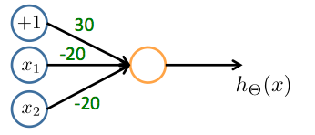

NAND (meaning "NOT AND")  
AND  
OR  
XOR (exclusive OR)

### Question 3

Consider the neural network given below. Which of the following equations correctly computes the activation $$a_1^{(3)}$$? Note: $$g(z)$$ is the sigmoid activation function.

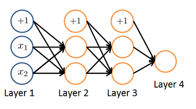

$$a_1^{(3)} = g(\Theta_{1,0}^{(2)}a_0^{(2)} \Theta_{1,1}^{(2)}a_1^{(2)} \Theta_{1,2}^{(2)}a_2^{(2)}) $$
$$a_1^{(3)} = g(\Theta_{1,0}^{(2)}a_0^{(1)} \Theta_{1,1}^{(2)}a_1^{(1)} \Theta_{1,2}^{(2)}a_2^{(1)}) $$
$$a_1^{(3)} = g(\Theta_{1,0}^{(1)}a_0^{(2)} \Theta_{1,1}^{(1)}a_1^{(2)} \Theta_{1,2}^{(1)}a_2^{(2)}) $$
$$a_1^{(3)} = g(\Theta_{2,0}^{(2)}a_0^{(2)} \Theta_{2,1}^{(2)}a_1^{(2)} \Theta_{2,2}^{(2)}a_2^{(2)}) $$

### Question 4

You have the following neural network:

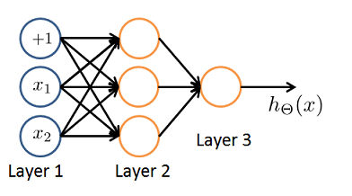

You'd like to compute the activations of the hidden layer $$a^{(2)} \in \mathbb{R}^3$$. One way to do so is the following Octave code:

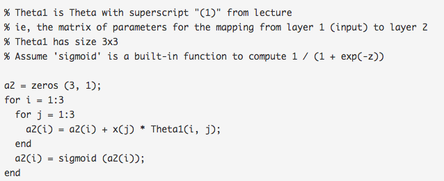

You want to have a vectorized implementation of this (i.e., one that does not use for loops). Which of the following implementations correctly compute $$a^{(2)}$$? Check all that apply.

a2 = sigmoid (Theta1 * x);  
a2 = sigmoid (x * Theta1);  
a2 = sigmoid (Theta2 * x);  
z = sigmoid(x); a2 = Theta1 * z;

### Question 5

You are using the neural network pictured below and have learned the parameters $$\Theta^{(1)} = \begin{bmatrix} 1 & 0.5 & 1.9 \\ 1 & 1.2 & 2.7\end{bmatrix}$$ (used to compute $$a^{(2)}$$) and $$\Theta^{(2)} = \begin{bmatrix} 1 & -0.2 & -1.7 \end{bmatrix}$$ (used to compute $$a^{(3)}$$} as a function of $$a^{(2)}$$). Suppose you swap the parameters for the first hidden layer between its two units so $$\Theta^{(1)} = \begin{bmatrix} 1 & 1.2 & 2.7 \\ 1 & 0.5 & 1.9 \end{bmatrix}$$ and also swap the output layer so $$\Theta^{(2)} = \begin{bmatrix} 1 & -1.7 & -0.2 \end{bmatrix}$$. How will this change the value of the output $$h_\Theta(x)$$?

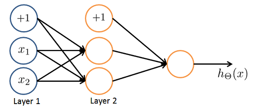

It will stay the same.  
It will increase.  
It will decrease  
Insufficient information to tell: it may increase or decrease.